# Máster en Data Science - Machine Learning

# Exploratory Data Analysis

##### Autor: Rodrigo Fernandez Campos

## DataSet: Bank Account Fraud Dataset Suite (NeurIPS 2022)

### Acerca del DataSet:

Se trata de una base de datos de aplicaciones para generar una cuenta bancaria. Cada instancia representa una aplicación, es decir, un individuo en este caso. He de destacar que en la descripción de la fuente de los datos se hace constante referencia y especial hincapié en que los datos NO representan valores reales que puedan vulnerar la confidencialidad de los usuarios. Los datos están completamente anonimizados y surgen de una generación sintética mediante modelos de Machine Learning aplicados por los autores del DataSet, basados en una base de datos de apertura de cuentas anonimizada de un banco real.

Vamos a trabajar con el dataset 'Base', uno de los 6 creados por los autores. Cada uno cuenta con 1 millón de instancias, incluido el que usaremos. Los datos han sido recavados en un período de 8 meses.

El link de Kaggle al post original del dataset es el siguiente: https://www.kaggle.com/datasets/sgpjesus/bank-account-fraud-dataset-neurips-2022/data

Además, en la carpeta "docs" se encuentra el PDF descriptivo de los datos explicado por los autores.

### Objetivos del Trabajo:

Los principales objetivos de esta primera práctica serán:

- Conocer el DataSet con el que vamos a trabajar
- Realizar un análisis de las variables que lo componen y un análisis general se sus instancias
- Comprender la distribución de los datos, las relaciones entre variables y sobre todo con la variable Target
- Depurarlo con el fin de aplicar modelos de Machine Learning sobre él en próximas entregas
- Dar concluisiones sobre cómo se conforma, sus principales componentes y qué podemos observar con un análisis exploratorio

## Business Case:

En la aplicación de un modelo de detección de fraude para aplicaciones bancarias se incluyen varios aspectos a tener en cuenta a la hora de desarrollar modelos de Machine Learning, tales como pueden ser el desbalanceo de los datos, los objetivos particulares de negocio del análisis o la capacidad de investigación sobre las alertas de detección que tenga la organización en cuestión. Todos estos conceptos deberán ser tenidos en cuenta no solo en el análisis, sino también en la implementación técnica, ya sea a la hora de explorar los datos como en el modelado y medición de resultados.

Con respecto a nuestro análisis, al tratarse de un modelo genérico y anonimizado, no contamos con directrices o información específica de un área de negocios, por lo que llevaremos adelante una serie de supuestos para determinar los lineamientos a seguir en cada fase del proyecto. Todos ellos serán explicados a continuación, intentando acercarnos mediante la lógica de negocio lo más posible a la realidad de una empresa que busca aplicar un modelo de detección de fraudes, con los beneficios y riesgos que esto implica, pero tratando de mejorar una situación inicial prácticamente sin modelo o con alguna regla muy simple (en nuestro caso, lo que llamaremos "Modelo Base").

Nuestro caso buscará predecir comportamientos fraudulentos de una mejor manera que la que lo harían modelos como series de reglas por ejemplo, los cuales podrán reemplazarse o funcionar de manera conjunta con nuestro modelo de Machine Learning, pero la ventaja que tendremos al aplicar este tipo de modelos, además de la automatización y dinamismo del mismo, será sobre todo el poder predecir patrones de conductas fraudulentas más complejos en donde actúan relaciones entre muchas más variables que las que un humano manualmente podría diseñar.

Normalmente este tipo de fraudes en aperturas de cuentas bancarias pueden comenzar cuando un agente malintencionado crea identidades falsas, robadas o sintéticas, o genera varias cuentas, a menudo mediante el uso de bots. Una vez dentro del sistema con una cuenta abierta, las posibilidades de generar un ataque serán mucho más amplias para este tipo de agentes. Es por esto que el modelo no solo busca determinar quien realizó un fraude y quien no, sino también entender porqué es más probable que un determinado tipo de usuario sea más propenso a estar categorizado como potencial fraude y poder aplicar a tiempo los límites y las técnicas de investigación adecuadas para el caso.

Es por este motivo que nuestro objetivo no será solo determinar fraude o no fraude, sino que la **potencialidad de fraude** (expresado en probabilidades) tomará un rol importante también, lo que por consecuencia lleva a que las mediciones de los resultados del modelo no serán categóricas en base a una sola métrica, ni estarán orientadas solo a medir que tan bien el modelo percibe quien cometió fraude y quien no. De ser ese el caso, la medida a utilizar sería el clasico *Accuracy*, métrica que indica la cantidad de aciertos sobre el total de los datos predecidos, pero en nuestro caso, dotaremos de una mayor importancia a medidas como lo son el *Recall* y la *Precision*, junto a los que las combinan, el *F1* y el *F2 score*, además de por supuesto a la clásica *matriz de confusión*. Vamos a ahondar un poco en esto a continuación, ya que es un tema importante a tener en cuenta.

Si somos coherentes con lo indicado, nos será más importante, debido a que representará un beneficio mayor vs. el modelo base, el poder detectar la mayor cantidad de potenciales casos fraudulentos. Esto implica por supuesto el riesgo de obtener *falsos negativos* (casos de fraude no detectados por el modelo) y *falsos positivos* (casos que no son fraudulentos pero que el modelo determina que si pueden serlo), pero los objetivos de negocio justifican el correr este riesgo debido a la gran ganancia potencial al detectar correctamente nuevos fraudes y por ende detectar lo que más buscamos: los **verdaderos positivos**.

Siguiendo esta lógica, las métricas mencionadas tendran vital importancia y en nuestro caso sobre todo he decidido dotar de la mayor importancia relativa al **F2 Score**, una métrica que conjunta precision y recall pero que, a diferencia del F1 score, otorga mayor preponderancia al Recall. Es decir, que con esta decisión buscaré premiar más a los modelos que, manteniendo un accuracy y una precision aceptables, me permitan detectar la mayor cantidad posible de potenciales fraudes de manera coherente, que luego serán analizados con mayor exhaustividad. Esto no quiere decir que solo me importe el Recall, debido a que también puede ser peligroso y muy costoso para una empresa tener que investigar demasiados casos por falta de precisión, por ello elijo el F2 por sobre simplemente el Recall. Esto desemboca en otro supuesto de negocio que deberemos realizar: la capacidad de investigación.

Al no contar con información de una empresa, no tenemos un número definido, pero al tratarse de modelos orientados a organizaciones de tipo bancario, que no solo consideramos que tendrían capacidad económica para financiar procesos de investigación, sino que además se trata de un área muy sensible del negocio tanto económica como reputacionalmente hablando, supondremos que se cuenta con cierta capacidad de investigación, por lo que será aceptable el tener más casos a investigar (corriendo el riesgo de caer en falsos positivos) pero buscando detectar más fraudes, que tener muy pocos casos por más que estemos seguros que serán fraudulentos. En caso de tener números concretos, esto podría llevarse a la práctica de manera efectiva agregando una matriz de costos al análisis. En este caso no podemos contar con ella, pero me parece interesante al menos tratar de mostrar un ejemplo de como la aplicaría para tener una mejor visión numérica de los objetivos de negocio del modelo.

Además de lo comentado, será importante tener en cuenta que los datos, como suele suceder en casos de este estilo, tendán un nivel de **desbalanceo** muy importante, es decir que los fraudes serán muchos menos casos que los regulares, lo cual por supuesto tendrá consecuencias, complicando tanto en el análisis como en el modelado y por ende requiriendo técnicas específicas para el tratamiento de set de datos con este tipo de sesgos tan marcados.

Finalmente, he de hacer una mención especial al apartado de la **explicabilidad** de los modelos que aplicaremos. Este concepto cada vez toma mayor relevancia en el mundo del data science en general, pero debemos tenerlo aún más en cuenta en casos del mundo de las finanzas, banca y aseguradoras debido no solo a la necesidad de comprensión de los modelos sino también a la creciente regulación gubernamental relativa a estos temas sensibles. Es por este motivo que realizaré un apartado especial referente a esta temática, intentando explicar de que manera el modelo toma las decisiones que toma para determinado tipo de comportamientos de los individuos.

He de matizar que no hablo de interpretabilidad y si de explicabilidad, debido a que dependiendo del modelo que elija, será posible ahondar más o menos en la precisión del análisis. Es decir, existen modelos que permiten tener un mayor entendimiento de su funcionamiento interno y determinar de manera prácticamente exacta de que manera afecta el valor de cada variable analizada al resultado final, como pueden ser por ejemplo modelos de regresión o de reglas, mientras que otro tipo de modelos que tienden más a clasificaciones complejas son más difíciles de interpretar de manera tan directa, como pueden ser las redes neuronales o los modelos de tipo bagging o boosting. Aún así, aplicando cierto tipo de librerías específicas para estos análisis, podremos aproximar una buena explicación en cuanto a cómo influyen las variables en las decisiones tomadas.

Una vez explicado en prufundidad, pasamos directamente a lo que refiere al entendimiento y tratamiento del dataset.

# Diccionario de datos:

#### El artículo descriptivo del DataFrame describe a cada una de las variables que lo componen de la siguiente manera:

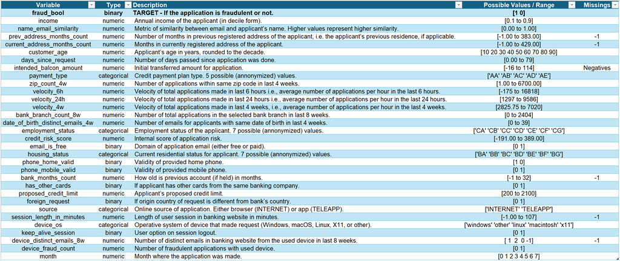

###### *Aclaración: que las variables sean numéricas no quiere decir que todas sean continuas, sino que se hace referencia al tipo de dato que contienen. Más adelante en el notebook veremos que algunas variables con tipos de datos numéricos son en realidad categorías, como se puede intuír por algunas descripciones.*

###### *Dichas variables tendrán su clasificación, tratamiento y explicación a lo largo de los notebooks de este EDA.*

# **Exploración inicial**

## Librerías

```python
# Librerías
import pandas as pd
import numpy as np
import matplotlib.pyplot as plt
import seaborn as sns
from sklearn.model_selection import train_test_split
import sweetviz as sv
from termcolor import colored, cprint
import sys

pd.set_option('display.max_columns', 500)
pd.set_option('display.max_rows', 500)
```

## Funciones

```python
sys.path.append('../src/')
import functions_rfc as fr
sys.path.remove('../src/')
```

## Importando el DataSet

```python
df_fraud = pd.read_csv('../data/raw/Base.csv')
df_fraud.head()
```

|  | fraud_bool | income | name_email_similarity | prev_address_months_count | current_address_months_count | customer_age | days_since_request | intended_balcon_amount | payment_type | zip_count_4w | velocity_6h | velocity_24h | velocity_4w | bank_branch_count_8w | date_of_birth_distinct_emails_4w | employment_status | credit_risk_score | email_is_free | housing_status | phone_home_valid | phone_mobile_valid | bank_months_count | has_other_cards | proposed_credit_limit | foreign_request | source | session_length_in_minutes | device_os | keep_alive_session | … |
| --- | --- | --- | --- | --- | --- | --- | --- | --- | --- | --- | --- | --- | --- | --- | --- | --- | --- | --- | --- | --- | --- | --- | --- | --- | --- | --- | --- | --- | --- | --- |
| 0 | 1 | 0.9 | 0.166828 | -1 | 88 | 50 | 0.020925 | -1.331345 | AA | 769 | 10650.765523 | 3134.319630 | 3863.647740 | 1 | 6 | CA | 185 | 0 | BA | 1 | 0 | 24 | 0 | 500.0 | 0 | INTERNET | 3.888115 | windows | 0 | … |
| 1 | 1 | 0.9 | 0.296286 | -1 | 144 | 50 | 0.005418 | -0.816224 | AB | 366 | 534.047319 | 2670.918292 | 3124.298166 | 718 | 3 | CA | 259 | 1 | BA | 0 | 0 | 15 | 0 | 1500.0 | 0 | INTERNET | 31.798819 | windows | 0 | … |
| 2 | 1 | 0.9 | 0.044985 | -1 | 132 | 40 | 3.108549 | -0.755728 | AC | 870 | 4048.534263 | 2893.621498 | 3159.590679 | 1 | 14 | CB | 177 | 1 | BA | 0 | 1 | -1 | 0 | 200.0 | 0 | INTERNET | 4.728705 | other | 0 | … |
| 3 | 1 | 0.9 | 0.159511 | -1 | 22 | 50 | 0.019079 | -1.205124 | AB | 810 | 3457.064063 | 4054.908412 | 3022.261812 | 1921 | 6 | CA | 110 | 1 | BA | 0 | 1 | 31 | 1 | 200.0 | 0 | INTERNET | 2.047904 | linux | 0 | … |
| 4 | 1 | 0.9 | 0.596414 | -1 | 218 | 50 | 0.004441 | -0.773276 | AB | 890 | 5020.341679 | 2728.237159 | 3087.670952 | 1990 | 2 | CA | 295 | 1 | BA | 1 | 0 | 31 | 0 | 1500.0 | 0 | INTERNET | 3.775225 | macintosh | 1 | … |

```python
# Diccionario de datos en dataset también:
var_description = pd.read_excel('../data/interim/variables_description.xlsx')
var_description.head()
```

|  | Variable | Type | Description | Possible Values / Range | Missings |
| --- | --- | --- | --- | --- | --- |
| 0 | fraud_bool | binary | TARGET - If the application is fraudulent or not. | [1 0] | NaN |
| 1 | income | numeric | Annual income of the applicant (in decile form). | [0.1 to 0.9] | NaN |
| 2 | name_email_similarity | numeric | Metric of similarity between email and applic... | [0.00 to 1.00] | NaN |
| 3 | prev_address_months_count | numeric | Number of months in previous registered addre... | [-1.00 to 383.00] | -1 |
| 4 | current_address_months_count | numeric | Months in currently registered address of the... | [-1.00 to 429.00] | -1 |

## Información básica del DataSet:

Con algunas funciones voy a ver cantidad y tipos de los datos, verificar existencia de nulos, etc.

```python
df_fraud.shape
```

```
(1000000, 32)
```

La tabla cuenta con 32 variables y 1 millón de instancias

```python
df_fraud.info()
```

```
<class 'pandas.core.frame.DataFrame'>
RangeIndex: 1000000 entries, 0 to 999999
Data columns (total 32 columns):
 #   Column                            Non-Null Count    Dtype
---  ------                            --------------    -----
 0   fraud_bool                        1000000 non-null  int64
 1   income                            1000000 non-null  float64
 2   name_email_similarity             1000000 non-null  float64
 3   prev_address_months_count         1000000 non-null  int64
 4   current_address_months_count      1000000 non-null  int64
 5   customer_age                      1000000 non-null  int64
 6   days_since_request                1000000 non-null  float64
 7   intended_balcon_amount            1000000 non-null  float64
 8   payment_type                      1000000 non-null  object
 9   zip_count_4w                      1000000 non-null  int64
```

[output cut: 24 more lines]

A priori parece que NO hay nulos, hay mucha variable tipo numérica, ya sea float o int (no quiere decir que sean numéricas si o si, pueden ser categóricas) y solo 5 tipo strings.

```python
df_fraud.dtypes.to_dict()
```

```
{'fraud_bool': dtype('int64'),
 'income': dtype('float64'),
 'name_email_similarity': dtype('float64'),
 'prev_address_months_count': dtype('int64'),
 'current_address_months_count': dtype('int64'),
 'customer_age': dtype('int64'),
 'days_since_request': dtype('float64'),
 'intended_balcon_amount': dtype('float64'),
 'payment_type': dtype('O'),
 'zip_count_4w': dtype('int64'),
 'velocity_6h': dtype('float64'),
 'velocity_24h': dtype('float64'),
 'velocity_4w': dtype('float64'),
 'bank_branch_count_8w': dtype('int64'),
 'date_of_birth_distinct_emails_4w': dtype('int64'),
 'employment_status': dtype('O'),
 'credit_risk_score': dtype('int64'),
 'email_is_free': dtype('int64'),
 'housing_status': dtype('O'),
 'phone_home_valid': dtype('int64'),
 'phone_mobile_valid': dtype('int64'),
 'bank_months_count': dtype('int64'),
 'has_other_cards': dtype('int64'),
 'proposed_credit_limit': dtype('float64'),
 'foreign_request': dtype('int64'),
 'source': dtype('O'),
 'session_length_in_minutes': dtype('float64'),
 'device_os': dtype('O'),
 'keep_alive_session': dtype('int64'),
 'device_distinct_emails_8w': dtype('int64'),
 'device_fraud_count': dtype('int64'),
 'month': dtype('int64')}
```

```python
df_fraud.describe()
```

|  | fraud_bool | income | name_email_similarity | prev_address_months_count | current_address_months_count | customer_age | days_since_request | intended_balcon_amount | zip_count_4w | velocity_6h | velocity_24h | velocity_4w | bank_branch_count_8w | date_of_birth_distinct_emails_4w | credit_risk_score | email_is_free | phone_home_valid | phone_mobile_valid | bank_months_count | has_other_cards | proposed_credit_limit | foreign_request | session_length_in_minutes | keep_alive_session | device_distinct_emails_8w | device_fraud_count | month |
| --- | --- | --- | --- | --- | --- | --- | --- | --- | --- | --- | --- | --- | --- | --- | --- | --- | --- | --- | --- | --- | --- | --- | --- | --- | --- | --- | --- |
| count | 1000000.000000 | 1000000.000000 | 1000000.000000 | 1000000.000000 | 1000000.000000 | 1000000.000000 | 1.000000e+06 | 1000000.000000 | 1000000.000000 | 1000000.000000 | 1000000.000000 | 1000000.000000 | 1000000.000000 | 1000000.000000 | 1000000.000000 | 1000000.000000 | 1000000.000000 | 1000000.000000 | 1000000.000000 | 1000000.000000 | 1000000.000000 | 1000000.000000 | 1000000.000000 | 1000000.000000 | 1000000.000000 | 1000000.0 | 1000000.000000 |
| mean | 0.011029 | 0.562696 | 0.493694 | 16.718568 | 86.587867 | 33.689080 | 1.025705e+00 | 8.661499 | 1572.692049 | 5665.296605 | 4769.781965 | 4856.324016 | 184.361849 | 9.503544 | 130.989595 | 0.529886 | 0.417077 | 0.889676 | 10.839303 | 0.222988 | 515.851010 | 0.025242 | 7.544940 | 0.576947 | 1.018312 | 0.0 | 3.288674 |
| std | 0.104438 | 0.290343 | 0.289125 | 44.046230 | 88.406599 | 12.025799 | 5.381835e+00 | 20.236155 | 1005.374565 | 3009.380665 | 1479.212612 | 919.843934 | 459.625329 | 5.033792 | 69.681812 | 0.499106 | 0.493076 | 0.313293 | 12.116875 | 0.416251 | 487.559902 | 0.156859 | 8.033106 | 0.494044 | 0.180761 | 0.0 | 2.209994 |
| min | 0.000000 | 0.100000 | 0.000001 | -1.000000 | -1.000000 | 10.000000 | 4.036860e-09 | -15.530555 | 1.000000 | -170.603072 | 1300.307314 | 2825.748405 | 0.000000 | 0.000000 | -170.000000 | 0.000000 | 0.000000 | 0.000000 | -1.000000 | 0.000000 | 190.000000 | 0.000000 | -1.000000 | 0.000000 | -1.000000 | 0.0 | 0.000000 |
| 25% | 0.000000 | 0.300000 | 0.225216 | -1.000000 | 19.000000 | 20.000000 | 7.193246e-03 | -1.181488 | 894.000000 | 3436.365848 | 3593.179135 | 4268.368423 | 1.000000 | 6.000000 | 83.000000 | 0.000000 | 0.000000 | 1.000000 | -1.000000 | 0.000000 | 200.000000 | 0.000000 | 3.103053 | 0.000000 | 1.000000 | 0.0 | 1.000000 |
| 50% | 0.000000 | 0.600000 | 0.492153 | -1.000000 | 52.000000 | 30.000000 | 1.517574e-02 | -0.830507 | 1263.000000 | 5319.769349 | 4749.921161 | 4913.436941 | 9.000000 | 9.000000 | 122.000000 | 1.000000 | 0.000000 | 1.000000 | 5.000000 | 0.000000 | 200.000000 | 0.000000 | 5.114321 | 1.000000 | 1.000000 | 0.0 | 3.000000 |
| 75% | 0.000000 | 0.800000 | 0.755567 | 12.000000 | 130.000000 | 40.000000 | 2.633069e-02 | 4.984176 | 1944.000000 | 7680.717827 | 5752.574191 | 5488.083356 | 25.000000 | 13.000000 | 178.000000 | 1.000000 | 1.000000 | 1.000000 | 25.000000 | 0.000000 | 500.000000 | 0.000000 | 8.866131 | 1.000000 | 1.000000 | 0.0 | 5.000000 |
| max | 1.000000 | 0.900000 | 0.999999 | 383.000000 | 428.000000 | 90.000000 | 7.845690e+01 | 112.956928 | 6700.000000 | 16715.565404 | 9506.896596 | 6994.764201 | 2385.000000 | 39.000000 | 389.000000 | 1.000000 | 1.000000 | 1.000000 | 32.000000 | 1.000000 | 2100.000000 | 1.000000 | 85.899143 | 1.000000 | 2.000000 | 0.0 | 7.000000 |

A simple vista se puede notar que habrá muchos booleanos y también categorías, por más que se traten de variables cuyos valores son numéricos. El Income y la Edad parecen estar agrupados por ejemplo.

```python
df_fraud.isna().sum()
```

```
fraud_bool                          0
income                              0
name_email_similarity               0
prev_address_months_count           0
current_address_months_count        0
customer_age                        0
days_since_request                  0
intended_balcon_amount              0
payment_type                        0
zip_count_4w                        0
velocity_6h                         0
velocity_24h                        0
velocity_4w                         0
bank_branch_count_8w                0
date_of_birth_distinct_emails_4w    0
employment_status                   0
credit_risk_score                   0
email_is_free                       0
housing_status                      0
phone_home_valid                    0
phone_mobile_valid                  0
bank_months_count                   0
has_other_cards                     0
proposed_credit_limit               0
foreign_request                     0
source                              0
session_length_in_minutes           0
device_os                           0
keep_alive_session                  0
device_distinct_emails_8w           0
device_fraud_count                  0
month                               0
dtype: int64
```

Confirmo la NO existencia de Nulls entre mis variables

```python
fr.duplicate_columns(df_fraud)
```

```
[]
```

Verifico que tampoco hay columnas duplicadas!

## Análisis sobre la variable Target

```python
df_fraud['fraud_bool'].value_counts(normalize=True)
# 0 es NO fraude y 1 si
```

```
fraud_bool
0    0.988971
1    0.011029
Name: proportion, dtype: float64
```

```python
df_fraud['fraud_bool'].value_counts()
```

```
fraud_bool
0    988971
1     11029
Name: count, dtype: int64
```

La variable 'fraud_bool' es el target que nos indica si se produjo fraude o no en la transacción

Como se puede notar, está claramente **desbalanceada**, hay solo un 1.1% de transacciones fraudulentas

```python
df_fraud.drop_duplicates().shape
```

```
(1000000, 32)
```

No pareciese haber duplicados exactos en principio

```python
target_count = df_fraud.groupby('fraud_bool').agg({'fraud_bool':'count'}).reset_index(drop=True)
target_count['value'] = list(target_count.index)
target_count
```

|  | fraud_bool | value |
| --- | --- | --- |
| 0 | 988971 | 0 |
| 1 | 11029 | 1 |

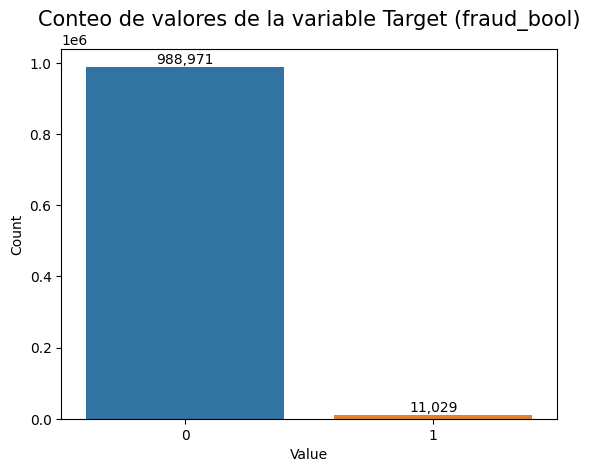

```python
fig, ax = plt.subplots()
sns.barplot(data=target_count, x='value', y='fraud_bool', ax=ax, hue='value', legend=False)
ax.set_title('Conteo de valores de la variable Target (fraud_bool)', fontdict={'fontsize':15}) #,'fontname':'Montserrat','weight':'bold'
ax.set_ylabel('Count')
ax.set_xlabel('Value')
for i in ax.containers:
    ax.bar_label(i,fmt='{:,.0f}')
plt.show()
```

# Análisis de tipos de las Variables

Voy a proceder a intentar determinar el tipo real de cada una de mis variables. Con esto no me refiero al tipo actual y el que tienen a simple vista, sino a realmente entender las características de la variable en cuanto a que tipo de infomación contiene.

Como ya he podido notar a simple vista con el describe, el dataset parece tener variables numéricas que en realidad contienen una categorización dentro suyo, ya sea porque se trate directamente de valores booleanos o porque hay codificaciones/agrupaciones de variables originalmente numéricas en categorías. Esto parece pasar con la edad, el ingreso, entre otras. Vamos a descubrirlo con el siguiente análisis.

```python
cat_vars = fr.dame_variables_categoricas(df_fraud)
cat_vars
```

```
(['fraud_bool',
  'customer_age',
  'payment_type',
  'date_of_birth_distinct_emails_4w',
  'employment_status',
  'email_is_free',
  'housing_status',
  'phone_home_valid',
  'phone_mobile_valid',
  'bank_months_count',
  'has_other_cards',
  'foreign_request',
  'source',
  'device_os',
  'keep_alive_session',
  'device_distinct_emails_8w',
  'device_fraud_count',
  'month'],
 ['prev_address_months_count',
  'current_address_months_count',
  'zip_count_4w',
  'bank_branch_count_8w',
  'credit_risk_score'])
```

```python
len(cat_vars[0])
```

```
18
```

```python
len(cat_vars[1])
```

```
5
```

```python
df_fraud.shape[1]
```

```
32
```

En este caso la función NO es del todo efectiva para mi análisis, pq no categoriza como quiero y deja afuera variables, por lo que voy a usar mi propia función para categorizar las variables a continuación:

```python
df_fraud.head()
```

|  | fraud_bool | income | name_email_similarity | prev_address_months_count | current_address_months_count | customer_age | days_since_request | intended_balcon_amount | payment_type | zip_count_4w | velocity_6h | velocity_24h | velocity_4w | bank_branch_count_8w | date_of_birth_distinct_emails_4w | employment_status | credit_risk_score | email_is_free | housing_status | phone_home_valid | phone_mobile_valid | bank_months_count | has_other_cards | proposed_credit_limit | foreign_request | source | session_length_in_minutes | device_os | keep_alive_session | … |
| --- | --- | --- | --- | --- | --- | --- | --- | --- | --- | --- | --- | --- | --- | --- | --- | --- | --- | --- | --- | --- | --- | --- | --- | --- | --- | --- | --- | --- | --- | --- |
| 0 | 1 | 0.9 | 0.166828 | -1 | 88 | 50 | 0.020925 | -1.331345 | AA | 769 | 10650.765523 | 3134.319630 | 3863.647740 | 1 | 6 | CA | 185 | 0 | BA | 1 | 0 | 24 | 0 | 500.0 | 0 | INTERNET | 3.888115 | windows | 0 | … |
| 1 | 1 | 0.9 | 0.296286 | -1 | 144 | 50 | 0.005418 | -0.816224 | AB | 366 | 534.047319 | 2670.918292 | 3124.298166 | 718 | 3 | CA | 259 | 1 | BA | 0 | 0 | 15 | 0 | 1500.0 | 0 | INTERNET | 31.798819 | windows | 0 | … |
| 2 | 1 | 0.9 | 0.044985 | -1 | 132 | 40 | 3.108549 | -0.755728 | AC | 870 | 4048.534263 | 2893.621498 | 3159.590679 | 1 | 14 | CB | 177 | 1 | BA | 0 | 1 | -1 | 0 | 200.0 | 0 | INTERNET | 4.728705 | other | 0 | … |
| 3 | 1 | 0.9 | 0.159511 | -1 | 22 | 50 | 0.019079 | -1.205124 | AB | 810 | 3457.064063 | 4054.908412 | 3022.261812 | 1921 | 6 | CA | 110 | 1 | BA | 0 | 1 | 31 | 1 | 200.0 | 0 | INTERNET | 2.047904 | linux | 0 | … |
| 4 | 1 | 0.9 | 0.596414 | -1 | 218 | 50 | 0.004441 | -0.773276 | AB | 890 | 5020.341679 | 2728.237159 | 3087.670952 | 1990 | 2 | CA | 295 | 1 | BA | 1 | 0 | 31 | 0 | 1500.0 | 0 | INTERNET | 3.775225 | macintosh | 1 | … |

```python
fr.tipos_vars(df_fraud)
```

```
fraud_bool (boolean) :  [1 0]
income (categoric) (Type: float64): [0.9 0.3 0.7 0.6 0.4 0.2 0.8 0.1 0.5]
name_email_similarity (numeric) : Range = [0.00 to 1.00], Mean = 0.49
prev_address_months_count (numeric) : Range = [-1.00 to 383.00], Mean = 16.72
current_address_months_count (numeric) : Range = [-1.00 to 428.00], Mean = 86.59
customer_age (categoric) (Type: int64): [50 40 30 20 70 60 80 10 90]
days_since_request (numeric) : Range = [0.00 to 78.46], Mean = 1.03
intended_balcon_amount (numeric) : Range = [-15.53 to 112.96], Mean = 8.66
payment_type (categoric) (Type: object): ['AA' 'AB' 'AC' 'AD' 'AE']
zip_count_4w (numeric) : Range = [1.00 to 6700.00], Mean = 1572.69
velocity_6h (numeric) : Range = [-170.60 to 16715.57], Mean = 5665.30
velocity_24h (numeric) : Range = [1300.31 to 9506.90], Mean = 4769.78
velocity_4w (numeric) : Range = [2825.75 to 6994.76], Mean = 4856.32
bank_branch_count_8w (numeric) : Range = [0.00 to 2385.00], Mean = 184.36
date_of_birth_distinct_emails_4w (categoric) (Type: int64): [ 6  3 14  2 13 10  1  4  5  9 11  8  7 17 21 12  0 18 19 15 22 16 24 23
 20 25 27 29 32 30 26 28 33 31 35 34 37 38 36 39]
employment_status (categoric) (Type: object): ['CA' 'CB' 'CC' 'CD' 'CE' 'CF' 'CG']
credit_risk_score (numeric) : Range = [-170.00 to 389.00], Mean = 130.99
email_is_free (boolean) :  [0 1]
housing_status (categoric) (Type: object): ['BA' 'BB' 'BC' 'BD' 'BE' 'BF' 'BG']
phone_home_valid (boolean) :  [1 0]
phone_mobile_valid (boolean) :  [0 1]
bank_months_count (categoric) (Type: int64): [24 15 -1 31 30 28 25  1 11 22  9 21  5 10  2 19 27  4  3 20 26 29  6 14
 16  7 12 18 23 32 13  8 17]
has_other_cards (boolean) :  [0 1]
proposed_credit_limit (categoric) (Type: float64): [ 500. 1500.  200. 2000. 1900. 1000.  990.  490.  510.  190.  210. 2100.]
foreign_request (boolean) :  [0 1]
source (categoric) (Type: object): ['INTERNET' 'TELEAPP']
session_length_in_minutes (numeric) : Range = [-1.00 to 85.90], Mean = 7.54
device_os (categoric) (Type: object): ['windows' 'other' 'linux' 'macintosh' 'x11']
keep_alive_session (boolean) :  [0 1]
device_distinct_emails_8w (categoric) (Type: int64): [ 1  2  0 -1]
device_fraud_count (boolean) :  [0]
month (categoric) (Type: int64): [7 3 2 1 6 0 5 4]
```

```
(['fraud_bool',
  'email_is_free',
  'phone_home_valid',
  'phone_mobile_valid',
  'has_other_cards',
  'foreign_request',
  'keep_alive_session',
  'device_fraud_count'],
 ['income',
  'customer_age',
  'payment_type',
  'date_of_birth_distinct_emails_4w',
  'employment_status',
  'housing_status',
  'bank_months_count',
  'proposed_credit_limit',
  'source',
  'device_os',
  'device_distinct_emails_8w',
  'month'],
 ['name_email_similarity',
  'prev_address_months_count',
  'current_address_months_count',
  'days_since_request',
  'intended_balcon_amount',
  'zip_count_4w',
  'velocity_6h',
  'velocity_24h',
  'velocity_4w',
  'bank_branch_count_8w',
  'credit_risk_score',
  'session_length_in_minutes'])
```

Una vez vistos los resultados de mi función, la cual me da una recomendación de que características tiene cada variable para clasificarlas tomo algunas decisiones en base al DF:

- Decido **eliminar la columna 'device_fraud_count'** debido a que solo tiene valor 0, por ende no proporciona información para el análisis ni para el modelo:

```python
df_fraud['device_fraud_count'].value_counts()
```

```
device_fraud_count
0    1000000
Name: count, dtype: int64
```

```python
df_fraud = df_fraud.drop('device_fraud_count', axis=1)
df_fraud.shape
```

```
(1000000, 31)
```

- Tambien voy a revisar la columna 'name_email_similarity', ya que salió como numérica pero sus valores están entre 0 y 1, por lo que voy a confirmar que **no** sea un booleano:

```python
df_fraud['name_email_similarity'].unique().shape
```

```
(998861,)
```

Ok, está bien categorizada como numérica.

```python
# Guardo en variables las listas que me da mi función de categorización de variables por tipo:
df_fraud_bool, df_fraud_cat, df_fraud_num = fr.tipos_vars(df_fraud,False)

df_fraud_bool, df_fraud_cat, df_fraud_num
```

```
(['fraud_bool',
  'email_is_free',
  'phone_home_valid',
  'phone_mobile_valid',
  'has_other_cards',
  'foreign_request',
  'keep_alive_session'],
 ['income',
  'customer_age',
  'payment_type',
  'date_of_birth_distinct_emails_4w',
  'employment_status',
  'housing_status',
  'bank_months_count',
  'proposed_credit_limit',
  'source',
  'device_os',
  'device_distinct_emails_8w',
  'month'],
 ['name_email_similarity',
  'prev_address_months_count',
  'current_address_months_count',
  'days_since_request',
  'intended_balcon_amount',
  'zip_count_4w',
  'velocity_6h',
  'velocity_24h',
  'velocity_4w',
  'bank_branch_count_8w',
  'credit_risk_score',
  'session_length_in_minutes'])
```

```python
var_types_count = pd.DataFrame([['Boolean',len(df_fraud_bool)]
                                ,['Categoric',len(df_fraud_cat)]
                                ,['Numeric',len(df_fraud_num)]]
                               , columns=['Var_type','Count'])
var_types_count
```

|  | Var_type | Count |
| --- | --- | --- |
| 0 | Boolean | 7 |
| 1 | Categoric | 12 |
| 2 | Numeric | 12 |

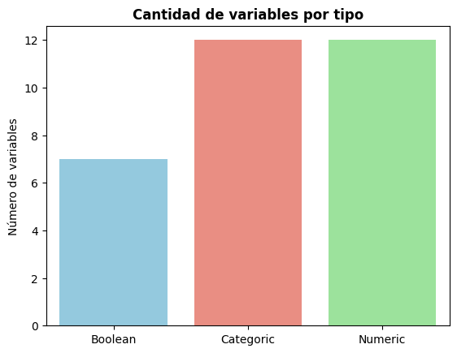

```python
fig, ax = plt.subplots()
sns.barplot(data=var_types_count,x='Var_type',y='Count', palette=['skyblue','salmon','lightgreen'], ax=ax, hue='Var_type')
ax.set_title('Cantidad de variables por tipo', weight='bold')
ax.set_ylabel('Número de variables')
ax.set_xlabel('')
plt.show()
```

```python
cat_vars = df_fraud[df_fraud_cat].dtypes.reset_index().rename(columns={'index':'Var',0:'dtype'})
cat_vars
```

|  | Var | dtype |
| --- | --- | --- |
| 0 | income | float64 |
| 1 | customer_age | int64 |
| 2 | payment_type | object |
| 3 | date_of_birth_distinct_emails_4w | int64 |
| 4 | employment_status | object |
| 5 | housing_status | object |
| 6 | bank_months_count | int64 |
| 7 | proposed_credit_limit | float64 |
| 8 | source | object |
| 9 | device_os | object |
| 10 | device_distinct_emails_8w | int64 |
| 11 | month | int64 |

```python
cat_vars_count = cat_vars.dtype.value_counts().sort_values().reset_index()
cat_vars_count
```

|  | dtype | count |
| --- | --- | --- |
| 0 | float64 | 2 |
| 1 | int64 | 5 |
| 2 | object | 5 |

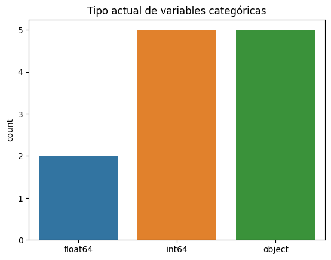

```python
sns.barplot(data=cat_vars_count,x='dtype',y='count',hue='dtype')
plt.xlabel('')
plt.title('Tipo actual de variables categóricas')
plt.show()
```

Como vemos, una buena parte de las variables que informan categorías de una manera u otra, actualmente están en formato numérico.

Es importante recalcar que **para éste análisis descriptivo, las variables serán consideradas categóricas**, ya que es su naturaleza. Es decir, a la hora de graficarlas, de realizar un análisis numérico tanto aislada como contra la variable objetivo y demás acciones, serán tratadas como categorías.

De igual manera, esto no implica que las vaya a transformar, ya que, como los valores que poseen son coherentes y están bien codificados, **a la hora de realizar el procesamiento de los datos y aplicar el modelo, lo mejor es mantener su estado actual como tipo de dato numérico**.

Ahora, antes de graficar las variables, quiero ver que porcentaje de valores manejan mis variables booleanas, además de para ver como se distribuyen, tambiíen porque puede que exista alguna otra variable con un comportamiento similar a la eliminada, pero si solo tuviese un valor distinto se hubiese saltado el control anterior:

```python
for i in df_fraud_bool:
    print(df_fraud[i].value_counts(normalize=True))
```

```
fraud_bool
0    0.988971
1    0.011029
Name: proportion, dtype: float64
email_is_free
1    0.529886
0    0.470114
Name: proportion, dtype: float64
phone_home_valid
0    0.582923
1    0.417077
Name: proportion, dtype: float64
phone_mobile_valid
1    0.889676
0    0.110324
Name: proportion, dtype: float64
has_other_cards
0    0.777012
1    0.222988
Name: proportion, dtype: float64
foreign_request
0    0.974758
1    0.025242
Name: proportion, dtype: float64
keep_alive_session
1    0.576947
0    0.423053
Name: proportion, dtype: float64
```

```python
# Lo mismo para las categóricas, esta vez teniendo en cuenta que hay de tipos string, int y float:
for i in df_fraud_cat:
    print(df_fraud[i].value_counts(normalize=True))
```

```
income
0.9    0.221419
0.1    0.157449
0.8    0.146650
0.6    0.111973
0.7    0.105109
0.4    0.081364
0.2    0.069345
0.5    0.055858
0.3    0.050833
Name: proportion, dtype: float64
customer_age
30    0.311433
20    0.245855
40    0.238712
50    0.140353
60    0.034770
10    0.020987
70    0.006517
80    0.001297
90    0.000076
Name: proportion, dtype: float64
payment_type
AB    0.370554
AA    0.258249
AC    0.252071
AD    0.118837
AE    0.000289
Name: proportion, dtype: float64
date_of_birth_distinct_emails_4w
7     0.083193
5     0.080799
8     0.079491
6     0.078225
11    0.073456
9     0.067341
10    0.062681
4     0.062549
13    0.060773
12    0.052409
```

[output cut: 110 more lines]

```
 1    0.968067
 2    0.025302
 0    0.006272
-1    0.000359
Name: proportion, dtype: float64
month
3    0.150936
2    0.136979
0    0.132440
4    0.127691
1    0.127620
5    0.119323
6    0.108168
7    0.096843
Name: proportion, dtype: float64
```

Cosas interesantes a tener en cuenta, como distribuciones de *Income* y *Edad*, que luego se verán mejor cuando las grafique.

También es algo a revisar con atención el hecho de que la variable 'source' tiene más del 99% de sus valores correspondientes solo a Internet, por lo que se deberá ver la relación con la variable Target y en el caso de que no aporte mucha información se podría eliminar por ser casi el mismo caso que *'device_fraud_count'*, variable anteriormente eliminada. Algo similar pero no tan extremo pasa con la variable *'device_distinct_emails_8w'*, en donde un gran porcentaje de sus datos es 1, aún así creo acorde mantenerla como está por el momento, ademáa vemos sus missings representan una proporción muy pequeña de sus datos.

```python
df_fraud[df_fraud.source == 'TELEAPP']
# Visualizo head y tail de la variable:
```

|  | fraud_bool | income | name_email_similarity | prev_address_months_count | current_address_months_count | customer_age | days_since_request | intended_balcon_amount | payment_type | zip_count_4w | velocity_6h | velocity_24h | velocity_4w | bank_branch_count_8w | date_of_birth_distinct_emails_4w | employment_status | credit_risk_score | email_is_free | housing_status | phone_home_valid | phone_mobile_valid | bank_months_count | has_other_cards | proposed_credit_limit | foreign_request | source | session_length_in_minutes | device_os | keep_alive_session | … |
| --- | --- | --- | --- | --- | --- | --- | --- | --- | --- | --- | --- | --- | --- | --- | --- | --- | --- | --- | --- | --- | --- | --- | --- | --- | --- | --- | --- | --- | --- | --- |
| 95 | 1 | 0.6 | 0.473524 | -1 | 26 | 30 | 10.965705 | -0.826556 | AB | 1297 | 4979.382900 | 4590.266738 | 3653.730707 | 9 | 10 | CB | 130 | 0 | BC | 0 | 1 | 28 | 0 | 200.0 | 0 | TELEAPP | 4.576058 | other | 0 | … |
| 125 | 1 | 0.1 | 0.551346 | -1 | 83 | 40 | 0.006407 | -1.170733 | AC | 821 | 1940.772340 | 2664.988566 | 3084.722825 | 0 | 1 | CC | 154 | 1 | BA | 0 | 1 | -1 | 0 | 500.0 | 0 | TELEAPP | 4.198877 | windows | 0 | … |
| 565 | 1 | 0.9 | 0.355917 | -1 | 182 | 30 | 0.007852 | -0.460982 | AB | 1756 | 3845.290298 | 2644.920199 | 3862.195925 | 1 | 11 | CA | 175 | 0 | BA | 1 | 0 | -1 | 0 | 200.0 | 0 | TELEAPP | 3.713880 | windows | 0 | … |
| 655 | 1 | 0.7 | 0.748737 | -1 | 317 | 50 | 0.004616 | -1.076265 | AC | 1562 | 4184.742915 | 3052.133218 | 3056.531340 | 0 | 1 | CA | 186 | 0 | BA | 1 | 0 | -1 | 0 | 2000.0 | 0 | TELEAPP | 3.342719 | other | 0 | … |
| 739 | 1 | 0.9 | 0.046007 | -1 | 103 | 60 | 0.014453 | -0.679327 | AC | 1952 | 891.917439 | 3664.088424 | 4977.665666 | 0 | 6 | CD | 141 | 1 | BA | 0 | 1 | -1 | 0 | 1000.0 | 0 | TELEAPP | 3.808501 | other | 0 | … |
| ... | ... | ... | ... | ... | ... | ... | ... | ... | ... | ... | ... | ... | ... | ... | ... | ... | ... | ... | ... | ... | ... | ... | ... | ... | ... | ... | ... | ... | ... | … |
| 999188 | 0 | 0.1 | 0.174547 | -1 | 194 | 70 | 3.641522 | -1.405628 | AB | 1430 | 12961.297037 | 5516.541423 | 4462.598131 | 1 | 3 | CC | 105 | 0 | BB | 1 | 1 | 28 | 0 | 200.0 | 0 | TELEAPP | -1.000000 | other | 0 | … |
| 999287 | 0 | 0.1 | 0.560361 | -1 | 42 | 30 | 2.411544 | -1.018177 | AC | 1906 | 3133.448421 | 5629.154703 | 4714.935835 | 1 | 7 | CA | 65 | 0 | BB | 1 | 1 | -1 | 1 | 1500.0 | 0 | TELEAPP | 4.776108 | other | 0 | … |
| 999672 | 0 | 0.9 | 0.360728 | -1 | 39 | 40 | 0.004396 | -0.997790 | AB | 2392 | 5289.632517 | 3746.954508 | 5097.344015 | 1757 | 5 | CA | 183 | 0 | BB | 1 | 1 | 30 | 0 | 1500.0 | 0 | TELEAPP | 4.957715 | other | 1 | … |
| 999675 | 0 | 0.6 | 0.577719 | -1 | 97 | 40 | 0.588675 | 52.091454 | AA | 1296 | 6816.056915 | 4918.725023 | 4920.733703 | 40 | 6 | CA | 198 | 0 | BE | 0 | 0 | 25 | 0 | 1500.0 | 0 | TELEAPP | 5.460101 | other | 1 | … |
| 999773 | 0 | 0.5 | 0.605762 | -1 | 37 | 30 | 0.004034 | 30.594138 | AB | 1045 | 3016.659485 | 4419.331198 | 4298.977173 | 7 | 14 | CB | 132 | 0 | BD | 0 | 1 | 21 | 1 | 200.0 | 0 | TELEAPP | 1.453450 | other | 0 | … |

7048 rows × 31 columns

```python
df_fraud[df_fraud.source == 'TELEAPP'].fraud_bool.value_counts(normalize=True)
```

```
fraud_bool
0    0.984109
1    0.015891
Name: proportion, dtype: float64
```

```python
df_fraud[df_fraud.source == 'INTERNET'].fraud_bool.value_counts(normalize=True)
```

```
fraud_bool
0    0.989006
1    0.010994
Name: proportion, dtype: float64
```

```python
df_fraud[df_fraud.source == 'TELEAPP'].fraud_bool.value_counts(normalize=True) / df_fraud[df_fraud.source == 'INTERNET'].fraud_bool.value_counts(normalize=True) - 1
```

```
fraud_bool
0   -0.004951
1    0.445363
Name: proportion, dtype: float64
```

Parece tener una tendencia muy similar a la distribución general con respecto a la variable target

```python
df_fraud[df_fraud.source == 'TELEAPP'].fraud_bool.value_counts()
```

```
fraud_bool
0    6936
1     112
Name: count, dtype: int64
```

En porcentaje parece poco pero son más de 7 mil registros que tienen esta diferenciación según source, y es un 40% más probable ver fraude con TeleApp que por Internet, por lo que la información, aunque sea poca, puede llegar a tener valor. También es superior al promedio general de fraud_bool, que es 0,0110 vs 0,0158

Creo que podrías ser una variable a eliminar pero en todo caso esto se podrá revisar a la hora de ejecutar el modelo y ver cuanto aporta dicha variable.

```python
df_fraud[df_fraud_num].describe().style.format(precision=4)
```

|  | name_email_similarity | prev_address_months_count | current_address_months_count | days_since_request | intended_balcon_amount | zip_count_4w | velocity_6h | velocity_24h | velocity_4w | bank_branch_count_8w | credit_risk_score | session_length_in_minutes |
| --- | --- | --- | --- | --- | --- | --- | --- | --- | --- | --- | --- | --- |
| count | 1000000.0000 | 1000000.0000 | 1000000.0000 | 1000000.0000 | 1000000.0000 | 1000000.0000 | 1000000.0000 | 1000000.0000 | 1000000.0000 | 1000000.0000 | 1000000.0000 | 1000000.0000 |
| mean | 0.4937 | 16.7186 | 86.5879 | 1.0257 | 8.6615 | 1572.6920 | 5665.2966 | 4769.7820 | 4856.3240 | 184.3618 | 130.9896 | 7.5449 |
| std | 0.2891 | 44.0462 | 88.4066 | 5.3818 | 20.2362 | 1005.3746 | 3009.3807 | 1479.2126 | 919.8439 | 459.6253 | 69.6818 | 8.0331 |
| min | 0.0000 | -1.0000 | -1.0000 | 0.0000 | -15.5306 | 1.0000 | -170.6031 | 1300.3073 | 2825.7484 | 0.0000 | -170.0000 | -1.0000 |
| 25% | 0.2252 | -1.0000 | 19.0000 | 0.0072 | -1.1815 | 894.0000 | 3436.3658 | 3593.1791 | 4268.3684 | 1.0000 | 83.0000 | 3.1031 |
| 50% | 0.4922 | -1.0000 | 52.0000 | 0.0152 | -0.8305 | 1263.0000 | 5319.7693 | 4749.9212 | 4913.4369 | 9.0000 | 122.0000 | 5.1143 |
| 75% | 0.7556 | 12.0000 | 130.0000 | 0.0263 | 4.9842 | 1944.0000 | 7680.7178 | 5752.5742 | 5488.0834 | 25.0000 | 178.0000 | 8.8661 |
| max | 1.0000 | 383.0000 | 428.0000 | 78.4569 | 112.9569 | 6700.0000 | 16715.5654 | 9506.8966 | 6994.7642 | 2385.0000 | 389.0000 | 85.8991 |

## Tratamiento de Missing Values:

#### De la descipción de variables por parte de los autores surgen de las siguientes descripciones la existencia de Missing Values codificados en algunos atributos del DataSet. Por ende las variables Missing a revisar serán las sigueintes:

- prev_address_months_count (numeric): Number of months in previous registered address of the applicant, i.e. the applicant’s previous residence, if applicable. Ranges between [−1, 380] months **(-1 is a missing value)**.
- current_address_months_count (numeric): Months in currently registered address of the applicant. Ranges between [−1, 429] months **(-1 is a missing value)**
- intended_balcon_amount (numeric): Initial transferred amount for application. Ranges between [−16, 114] **(negatives are missing values).**
- bank_months_count (numeric): How old is previous account (if held) in months. Ranges between [−1, 32] months **(-1 is a missing value).**
- session_length_in_minutes (numeric): Length of user session in banking website in minutes. Ranges between [−1, 107] minutes **(-1 is a missing value).**
- device_distinct_emails (numeric): Number of distinct emails in banking website from the used device in last 8 weeks. Ranges between [−1, 2] emails **(-1 is a missing value).**

En muchas variables, más que nada en las numéricas (también en alguna categórica), los valores en negativo son MISSING, por lo que hay que determinar como los vamos a tratar

- prev_address_months_count
- current_address_months_count
- intended_balcon_amount
- bank_months_count
- session_length_in_minutes
- device_distinct_emails

```python
df_fraud_cat, df_fraud_num
```

```
(['income',
  'customer_age',
  'payment_type',
  'date_of_birth_distinct_emails_4w',
  'employment_status',
  'housing_status',
  'bank_months_count',
  'proposed_credit_limit',
  'source',
  'device_os',
  'device_distinct_emails_8w',
  'month'],
 ['name_email_similarity',
  'prev_address_months_count',
  'current_address_months_count',
  'days_since_request',
  'intended_balcon_amount',
  'zip_count_4w',
  'velocity_6h',
  'velocity_24h',
  'velocity_4w',
  'bank_branch_count_8w',
  'credit_risk_score',
  'session_length_in_minutes'])
```

Tenemos 4 variables numéricas con missings y 2 categóricas

```python
cols_with_mis = ['prev_address_months_count'
            ,'current_address_months_count'
            ,'intended_balcon_amount'
            ,'bank_months_count'
            ,'session_length_in_minutes'
            ,'device_distinct_emails_8w']
```

```python
#for i in cols_with_mis:
#    print(i, " : ", var_description.set_index('Variable').loc[i,'Description'])

fr.dame_info(cols_with_mis, df_fraud, var_description, only_desc=True)
# Veo la descripción de cada variable para volver a revisar de que se compone cada una y analizar los missings en contexto
```

```
 1. prev_address_months_count  :  Number of months in previous registered address of the applicant, i.e. the applicant’s previous residence, if applicable.
 2. current_address_months_count  :  Months in currently registered address of the applicant.
 3. intended_balcon_amount  :  Initial transferred amount for application.
 4. bank_months_count  :  How old is previous account (if held) in months.
 5. session_length_in_minutes  :  Length of user session in banking website in minutes.
 6. device_distinct_emails_8w  :  Number of distinct emails in banking website from the used device in last 8 weeks.
```

```python
df_fraud[cols_with_mis][df_fraud[cols_with_mis] < 0].count()/df_fraud.shape[0]
```

```
prev_address_months_count       0.712920
current_address_months_count    0.004254
intended_balcon_amount          0.742523
bank_months_count               0.253635
session_length_in_minutes       0.002015
device_distinct_emails_8w       0.000359
dtype: float64
```

Bueno, lo que en principio parecían ser pocos missings, ahora parece ser que hablamos de columnas con muchos datos de este tipo.

Las más preocupantes son claramente prev_adress_months_count y intended_balcon_amount

```python
df_fraud[df_fraud['prev_address_months_count'] < 0].fraud_bool.value_counts(normalize=True)
```

```
fraud_bool
0    0.985785
1    0.014215
Name: proportion, dtype: float64
```

```python
df_fraud[df_fraud['prev_address_months_count'] > 0].fraud_bool.value_counts(normalize=True)
```

```
fraud_bool
0    0.996882
1    0.003118
Name: proportion, dtype: float64
```

Aunque la tendencia sea relativamente similar, se puede notar una diferencia entre lo que pasa cuando los valores son missing o no, es decir que, a pesar de ser muchos los missings, pueden darme algún tipo de información

```python
df_fraud[df_fraud['intended_balcon_amount'] < 0].fraud_bool.value_counts(normalize=True)
```

```
fraud_bool
0    0.986873
1    0.013127
Name: proportion, dtype: float64
```

```python
df_fraud[df_fraud['intended_balcon_amount'] > 0].fraud_bool.value_counts(normalize=True)
```

```
fraud_bool
0    0.995021
1    0.004979
Name: proportion, dtype: float64
```

Lo mismo pasa con esta columna! Vemos que, aunque parezca poca la diferencia, en realidad hablamos de que cuando el valor es missing, las chances de que haya fraude mucho más altas comparándolo vs cuando la variable no tiene un valor missing. Esta información puede ser útil, por lo que debería mantenerla.

```python
df_fraud[df_fraud['intended_balcon_amount'] < 0].fraud_bool.value_counts(normalize=True) / df_fraud[df_fraud['intended_balcon_amount'] > 0].fraud_bool.value_counts(normalize=True) -1
```

```
fraud_bool
0   -0.008189
1    1.636401
Name: proportion, dtype: float64
```

### En conclusión, sobre las variables que tienen muchos Missing Values:

Creo que **no** amerita una transformación (ya que el missing ya está correctamente codificado, al ser negativo es bien diferente del resto de los valores y no es un Null) y tampoco amerita sacar la columna del análisís, ya que nos puede brindar información. Solo hay dos variables que rondan el 70% y en el resto los porcentajes son bajos, ninguna ronda el 90% de valores missings, porcentaje que ya nos haría evaluar el eliminar dicha variable del modelo.

Cabe destacar que esto además me parece lógico debido al tipo de proyecto que estamos tratando. En otros modelos la falta de datos puede ser simplemente falta de información, pero en este caso de aplicaciones a cuentas bancarias y detección de fraude, el que no exista información, ya sea porque el cliente no la ha cargado, porque el proveedor de datos no posee información de ese cliente o por cualquier razón, nos puede indicar algo sobre el potencial del fraude. Es decir, en este caso particular de análisis el hecho de no poseer información sobre alguien puede ser información útil también.

Por ende, se mantendrán las variables con missings y su codificación actual ya que es útil así. De igual manera, a la hora de ejecutar los modelos será un aspecto a tener en cuenta, para ver si afectan de manera negativa o no.

# Tipos finales de las variables

Modificaré los valores de las variables categóricas para que dejen de ser tipo 'object' y pasen a ser tipo 'category'.

**(**No recategorizo todas las variables categóricas, ya que, como comenté con anterioirdad, me sirve que sean numéricas en la manera en la que lo son, es decir, las tengo identificadas como categóricas, pero me sirve que los booleanos tomen valores 0 y 1, y también considero que las demás variables categóricas con valores numéricos están bien así para el análisis, ya que de pasarlas a categóricas luego debería volver a codificarlas numéricamente.**)**

```python
df_fraud[df_fraud_cat].dtypes
```

```
income                              float64
customer_age                          int64
payment_type                         object
date_of_birth_distinct_emails_4w      int64
employment_status                    object
housing_status                       object
bank_months_count                     int64
proposed_credit_limit               float64
source                               object
device_os                            object
device_distinct_emails_8w             int64
month                                 int64
dtype: object
```

```python
df_fraud[['payment_type','employment_status','housing_status','source','device_os']] = df_fraud[['payment_type','employment_status','housing_status','source','device_os']]\
.astype("category")
df_fraud.dtypes
```

```
fraud_bool                             int64
income                               float64
name_email_similarity                float64
prev_address_months_count              int64
current_address_months_count           int64
customer_age                           int64
days_since_request                   float64
intended_balcon_amount               float64
payment_type                        category
zip_count_4w                           int64
velocity_6h                          float64
velocity_24h                         float64
velocity_4w                          float64
bank_branch_count_8w                   int64
date_of_birth_distinct_emails_4w       int64
employment_status                   category
credit_risk_score                      int64
email_is_free                          int64
housing_status                      category
phone_home_valid                       int64
phone_mobile_valid                     int64
bank_months_count                      int64
has_other_cards                        int64
proposed_credit_limit                float64
foreign_request                        int64
source                              category
session_length_in_minutes            float64
device_os                           category
keep_alive_session                     int64
device_distinct_emails_8w              int64
month                                  int64
dtype: object
```

# Exportación parcial del DataSet

Para no alargar más este notebook, procedo a exportar a CSV el estado actual del DataSet y prosigo en el siguiente notebook con el próximo apartado de mi análisis

```python
df_fraud.to_csv('../data/interim/df_fraud_1.csv')
```

# EDA Automático:

Finalmente, expongo que también he solicitado a SweetViz un análisis automático de las variables del DF con el siguiente código:

```python
#report=sv.analyze(df_fraud)
#report.show_html('eda_report.html')
```

El HTML contenedor del reporte se encuentra en la carpeta 'html', con el nombre de "**eda_report.html**"